# Sentiment Analysis

Wouter van Atteveldt  
Glasgow Text Analysis, 2016-11-17

### Sentiment Analysis

- What is the tone of a text?
- Techniques (e.g. Pang/Lee 2008, Liu 2012)
  - Manual coding
  - Dictionaries
  - Machine Learning
  - Crowdsourcing (Benoit ea 2015)
- See e.g. [https://www.cs.uic.edu/~liub/FBS/NLP-handbook-sentiment-analysis.pdf](https://www.cs.uic.edu/%7Eliub/FBS/NLP-handbook-sentiment-analysis.pdf)

### Sentiment Analysis: problems

*“The man who leaked cell-phone coverage of Saddam Hussein's execution was arrested”*

- Language is subjective, ambiguous, creative
- What does positive/negative mean?
  - e.g. Osgood ea 1957: evaluation, potency, activity
- Who is positive/negative about what?
  - Sentiment Attribution

### Sentiment Analysis resources

- Lexicon (dictionary)
- Annotated texts
- Tools / models

### Lexical Sentiment Analysis

- Get list of positive / negative terms
- Count occurrences in text
- Summarize to sentiment score
- Possible improvements
  - Word-window approach (tomorrow)
  - Deal with negation, intensification

### Lexical Sentiment Analysis in R

- Nothing new here!
- Directly count words in DTM:

```r
lex = list(pos=c("good", "nice", "great"), neg=c("bad","stupid", "crooked"))
library(slam)
npos = row_sums(dtm[, colnames(dtm) %in% lex$pos])
nneg = row_sums(dtm[, colnames(dtm) %in% lex$neg])
sent = data.frame(id=rownames(dtm), npos=npos, nneg=nneg)
sent$subj = sent$npos + sent$nneg
sent$sent = ifelse(sent$subj == 0, 0,
                   (sent$npos-sent$nneg) / (sent$subj))
sent = merge(meta, sent)
Head(sent)
```

| id | date | medium | year | month | week | npos | nneg | subj | sent |
| --- | --- | --- | --- | --- | --- | --- | --- | --- | --- |
| 162317736 | 2016-02-01 | The New York Times | 2016-01-01 | 2016-02-01 | 2016-02-01 | 0 | 0 | 0 | 0 |
| 162317809 | 2016-01-25 | The New York Times | 2016-01-01 | 2016-01-01 | 2016-01-25 | 0 | 0 | 0 | 0 |
| 171932192 | 2016-07-04 | The New York Times | 2016-01-01 | 2016-07-01 | 2016-07-04 | 0 | 0 | 0 | 0 |
| 171932219 | 2016-07-03 | The New York Times | 2016-01-01 | 2016-07-01 | 2016-06-27 | 1 | 0 | 1 | 1 |
| 171932226 | 2016-07-03 | The New York Times | 2016-01-01 | 2016-07-01 | 2016-06-27 | 0 | 0 | 0 | 0 |
| 171932227 | 2016-07-03 | The New York Times | 2016-01-01 | 2016-07-01 | 2016-06-27 | 0 | 0 | 0 | 0 |

### Lexical Sentiment Analysis in R

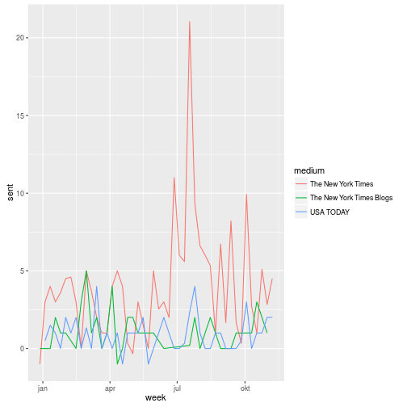

```r
a = aggregate(sent[c("sent", "subj")],
              sent[c("week", "medium")], sum)
library(ggplot2)
ggplot(a, aes(x=week, y=sent, colour=medium)) +
  geom_line()
```

### Lexical Sentiment Analysis: Alternatives

Apply directly to tokenlist:

```r
tokens$sent =0
tokens$sent[tokens$lemma %in% lex$pos] = 1
Head(tokens[tokens$sent > 0,])
```

|  | id | sentence | offset | word | lemma | POS | POS1 | ner | sent |
| --- | --- | --- | --- | --- | --- | --- | --- | --- | --- |
| 230726 | 171932219 | 50 | 3857 | good | good | JJ | G | O | 1 |
| 316450 | 171932322 | 2 | 193 | good | good | JJ | G | O | 1 |
| 431087 | 171932429 | 22 | 3577 | Good | good | JJ | G | O | 1 |
| 547654 | 171932557 | 17 | 1848 | good | good | JJ | G | O | 1 |
| 547812 | 171932557 | 25 | 2589 | great | great | JJ | G | O | 1 |
| 560047 | 171932568 | 13 | 2011 | good | good | JJ | G | O | 1 |

### Lexical Sentiment Analysis: Quanteda

```r
library(quanteda)
library(corpustools)
dfm = dtm.to.dfm(dtm)
dfm = applyDictionary(dfm, lex)
head(dfm)
```

```
Document-feature matrix of: 999 documents, 2 features (0% sparse).
(showing first 6 documents and first 2 features)
           features
docs        pos neg
  162317736   0   0
  162317809   0   0
  171932192   0   0
  171932219   1   0
  171932226   0   0
  171932227   0   0
```

### Acquiring a lexicon

- Many sentiment lexicons exist
  - [wordstat, LIWC, lexicoder, harvard IV, …](https://provalisresearch.com/products/content-analysis-software/wordstat-dictionary/sentiment-dictionaries/)
  - [Liu's opinion lexicon](https://www.cs.uic.edu/%7Eliub/FBS/sentiment-analysis.html#lexicon)
  - [Wiebe's subjectivity lexicon](http://mpqa.cs.pitt.edu/)
- Download, run, evaluate

## Parsing a sentiment lexicon

### Parsing a sentiment lexicon

```r
lex = readRDS("lexicon.rds")
dict = list(
  pos = lex$word1[lex$priorpolarity == "positive"],
  neg = lex$word1[lex$priorpolarity == "negative"],
  trump = "Trump",
  clinton = c("Hillary", "Clinton"))
```

### Proximity-based sentiment analysis

- Political texts contain multiple statements
- Apply words to actors in close proximity
  - Within sentence/paragraph -> create dtm/dfm at sentence level
  - Within N words -> use token list
- However, “Trump calls Clinton crooked”
  - clause anlaysis (http://vanatteveldt.com/2016-clause-analysis/)

### Sentence-level sentiment:

```r
tokens$doc = paste(tokens$id, tokens$sentence, sep="_")
dtm = dtm.create(tokens$doc, tokens$lemma, minfreq = 10)
x = sapply(dict, function(x)
  row_sums(dtm[, colnames(dtm) %in% x]))
Head(x)
```

|  | pos | neg | trump | clinton |
| --- | --- | --- | --- | --- |
| 162317736_1 | 2 | 2 | 0 | 0 |
| 162317736_2 | 2 | 4 | 0 | 0 |
| 162317736_3 | 0 | 1 | 0 | 0 |
| 162317736_4 | 1 | 2 | 0 | 0 |
| 162317736_5 | 3 | 1 | 0 | 0 |
| 162317736_6 | 0 | 4 | 0 | 0 |

### Proximity-based sentiment: semnet

```r
devtools::install_github("kasperwelbers/semnet")
```

```r
library(semnet)
tokens$concept = NA
for(c in names(dict))
  tokens$concept[tokens$lemma %in% dict[[c]]] = c

hits = windowedCoOccurenceNetwork(location=tokens$offset,
    term=tokens$concept, context=tokens$id,
    window.size=40, output.per.context = T)
hits = subset(hits, x %in% c("clinton", "trump")
              & y %in% c("pos", "neg"))
hits$sent = ifelse(hits$y == "pos", 1, -1)
tapply(hits$sent, droplevels(hits$x), mean)
```

```
   clinton      trump
0.10921228 0.02649982
```

### Sentiment Analysis: difficulty

- Liu: “Although necessary, having an opinion lexicon is far from sufficient for accurate sentiment analysis” … “sentiment analysis tasks are very challenging.”
- “[sentistrength] has human-level accuracy for short social web texts in English, except political texts.”
- Subjective language is
  - Creative
  - Ambiguous
  - Subjective
  - Content-sensitive
- Political communication is (often) nuanced, complicated

### Improving sentiment analysis

- Domain adaptation
  - Get term statistics
  - Merge with lexicon
  - Manually check top-X frequent words
- Targeted sentiment anlaysis (next section)
- Crowd sourcing (e.g. Haselmayer in press)
- Machine learning (see handout)

## Hands-on session III

- Sentiment Analysis of election campaign
  - (or your own data …)
- What is the overall sentiment?
  - Development over time, per medium
- What is sentiment for different actors?
- Try out different lexica
- Try to adapt lexicon to domain

## Conclusion

- Frequency-based text analysis
  - Corpus analysis and topic modeling
  - Natural language procesessing
  - Sentiment Analysis
- Lots of resources out there
  - See e.g. vanatteveldt.com/glasgow-r
- Questions?